# R-ladies 21.08.2019

Gunn-Helen Moen

# Quick introduction to Rmarkdown

You write your document in plain text and you can include *italics* and **bold** formats in addition to superscript<sup>2</sup> and links. When you want a new paragraph you end the line with two spaces. You can insert a header by using one or more hashtags:

# Header 1

## Header 2

### and so on

> block quotes
- unordered lists
- with several items
- and sub-items
- more sub-items
1. Ordered lists
2. Like this
- with adidional sub-items

You can also make tables:

| Table header 1 | Table header 2 |
| --- | --- |
| Cell 1 | Cell 2 |
| Cell 3 | Cell 4 |

To add a code chunck to your document write three back ticks followed by {r}. To end the code chunck add three more back ticks.

```r
paste("Hello", "R-ladies!")
```

```
## [1] "Hello R-ladies!"
```

Within the braces you can add chuck options, `echo=FALSE` will prevent the source code from being displayed and the code will look like this:

```
## [1] "Hello R-ladies!"
```

Another usefull one is `eval=TRUE` for running the code in the code chunk and `eval=FALSE` for not running the code in the code chunk. To add comments to your code just use # withing the code chuck window

```r
paste("Hello", "R-ladies!") #Add comment
```

[output not shown]

# ggplot2

GGplot2 is one of the graphing library’s in R.

```r
#install.packages("ggplot2")
library("ggplot2")
```

### ggplot2 graphing consists of three parts

1. **aesthetic**
- An aesthetic that tells ggplot which variables are being mapped to the x axis, y axis, (and often other attributes of the graph, such as the color fill). Intuitively, the aesthetic can be thought of as what you are graphing.
2. **geom**
- A geom or geometry that tells ggplot about the basic structure of the graph. Intuitively, the geom can be thought of as how you are graphing it.
3. **options**
- Other options, such as a graph title, axis labels and overall theme for the graph. —

##### For this demonstration I will use the R example data mtcars.

Loading the data and having a look:

```r
data(mtcars)
head(mtcars)
```

```
##                    mpg cyl disp  hp drat    wt  qsec vs am gear carb
## Mazda RX4         21.0   6  160 110 3.90 2.620 16.46  0  1    4    4
## Mazda RX4 Wag     21.0   6  160 110 3.90 2.875 17.02  0  1    4    4
## Datsun 710        22.8   4  108  93 3.85 2.320 18.61  1  1    4    1
## Hornet 4 Drive    21.4   6  258 110 3.08 3.215 19.44  1  0    3    1
## Hornet Sportabout 18.7   8  360 175 3.15 3.440 17.02  0  0    3    2
## Valiant           18.1   6  225 105 2.76 3.460 20.22  1  0    3    1
```

The structure of building a ggplot consist of a `aesthetic` + `one or more geoms` + `optional elements`.

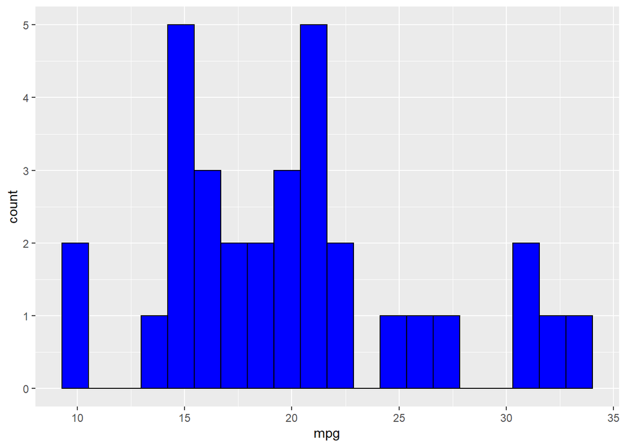

```r
ggplot(mtcars, #my dataset
aes(x=mpg)) + #what I am graphing - here miles per gallon from mtcars dataset
geom_histogram(fill="blue", #how is it being graphed
color="black",
bins = 20)
```

From here you can start adding labels

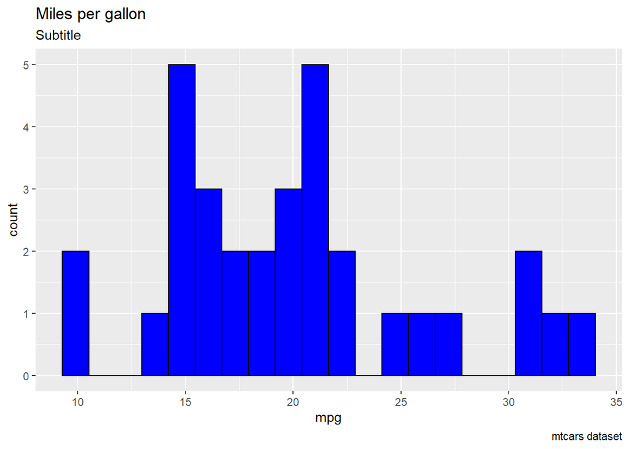

```r
ggplot(mtcars, #my dataset
aes(x=mpg)) + #what I am graphing - here miles per gallon from mtcars dataset
geom_histogram(fill="blue", #how is it being graphed
color="black",
bins = 20) +
labs(title = "Miles per gallon",
subtitle = "Subtitle",
caption = "mtcars dataset",
x = "mpg",
y = "count")
```

##### Assigning the aesthetic to an plot You can assign your basic ggplot function to a plot so that you wont have to call it everytime. For instance:

```r
p<- ggplot(mtcars, aes(x=mpg))
```

#### The different geoms

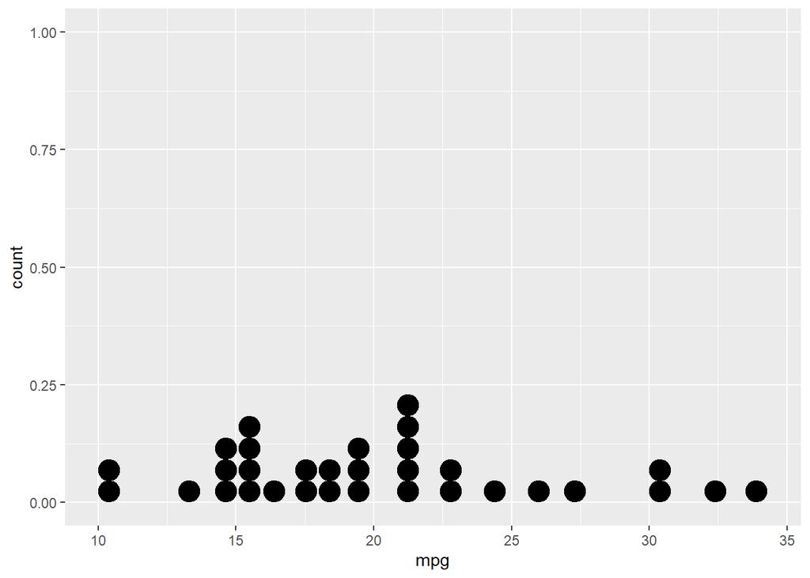

```r
p + geom_dotplot()
```

```r
p2<- ggplot(mtcars, aes(x=mpg, y=hp))
#two continous variables (miles pergallon and horsepower)
```

Examples of plots: Scatterplot:

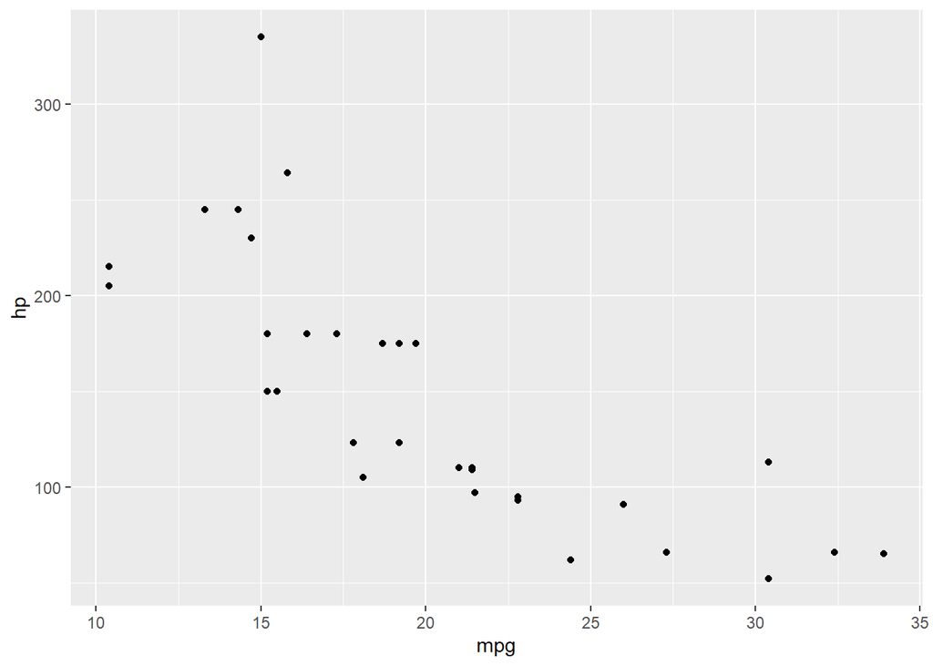

```r
p2 + geom_point()
```

Scatterplot with Smoother:

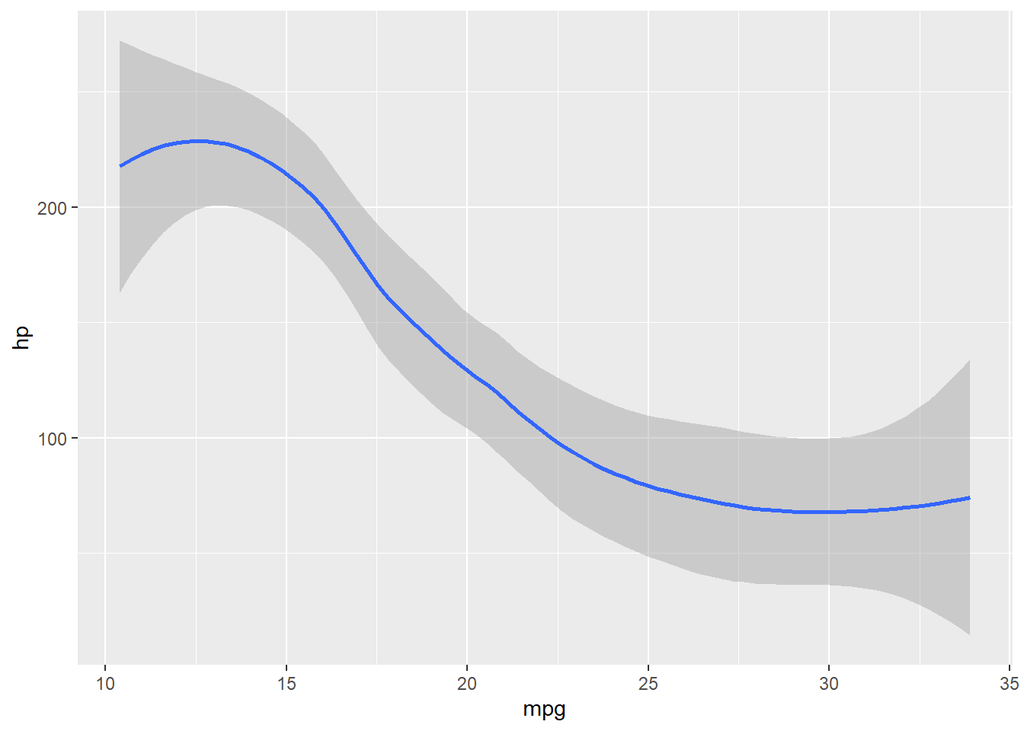

```r
p2 + geom_smooth()
```

Combining the two:

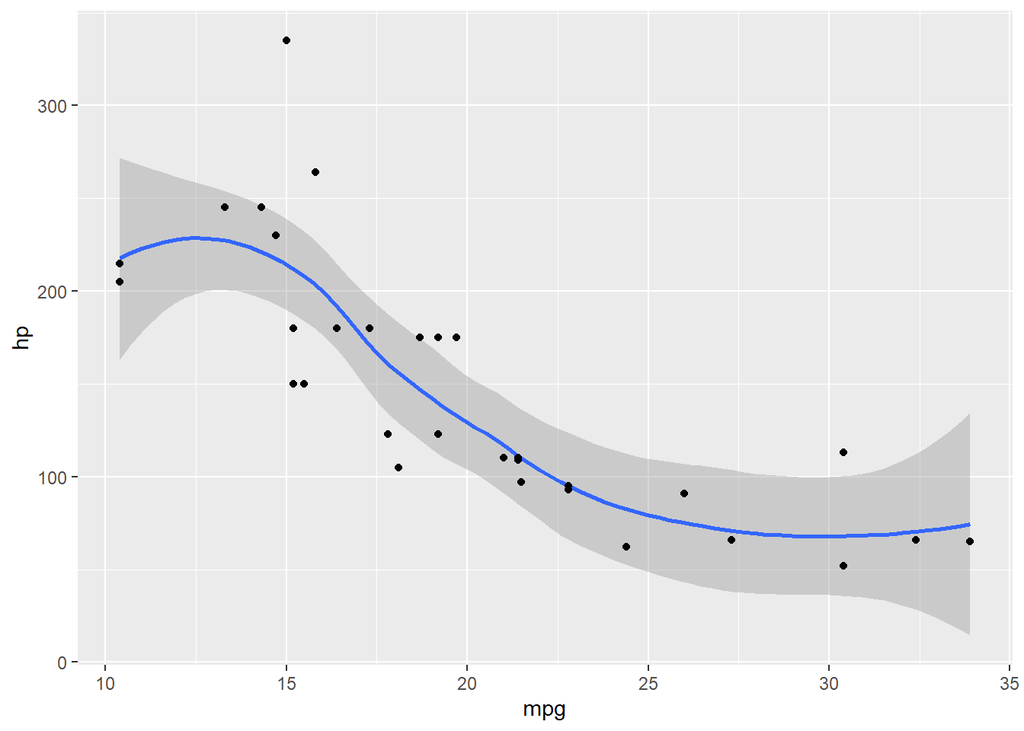

```r
p2 + geom_smooth() + geom_point()
```

#### Saving your plot

Save your plot by using `ggsave("plot.png", width = 5, height = 5)`

[ggplot2 cheetsheet is a usefull resourse](https://github.com/rstudio/cheatsheets/blob/master/data-visualization-%202.1.pdf)